# Class 24

Tobias Gerstenberg

# 24 Bayesian data analysis 4

## 24.1 Learning goals

- Evidence for null results.
- Dealing with unequal variance.
- Zero-one inflated beta binomial model.
- Ordinal logistic regression.

## 24.2 Load packages and set plotting theme

```r
library("knitr")      # for knitting RMarkdown
library("kableExtra") # for nice RMarkdown tables
library("janitor")    # for cleaning column names
library("modelr")     # for doing modeling stuff
library("tidybayes")  # tidying up results from Bayesian models
library("brms")       # Bayesian regression models with Stan
library("rstanarm")   # for Bayesian models
library("patchwork")  # for making figure panels
library("ggrepel")    # for labels in ggplots
library("broom")      # for tidying things up
library("gganimate")  # for animations
library("GGally")     # for pairs plot
library("patchwork")  # for figure panels
library("bayesplot")  # for visualization of Bayesian model fits
library("ggeffects")  # for showing marginal/conditional effects
library("scales")     # for percent y-axis
library("tidyverse")  # for wrangling, plotting, etc.
```

```r
theme_set(theme_classic() + #set the theme
            theme(text = element_text(size = 20))) #set the default text size

# set rstan options
rstan::rstan_options(auto_write = TRUE)
options(mc.cores = parallel::detectCores())
```

## 24.3 Evidence for the null hypothesis

See [this tutorial](https://vuorre.netlify.com/post/2017/03/21/bayes-factors-with-brms/) and this paper (Wagenmakers et al. 2010) for more information.

### 24.3.1 Fit the model

- Define a binomial model
- Give a uniform prior `beta(1, 1)`
- Get samples from the prior

```r
df.null = tibble(s = 6, k = 10)

fit.brm0 = brm(s | trials(k) ~ 0 + Intercept,
               family = binomial(link = "identity"),
               prior = set_prior("beta(1, 1)", class = "b", lb = 0, ub = 1),
               data = df.null,
               sample_prior = TRUE,
               cores = 4,
               file = "cache/brm0")
```

### 24.3.2 Visualize the results

Visualize the prior and posterior samples:

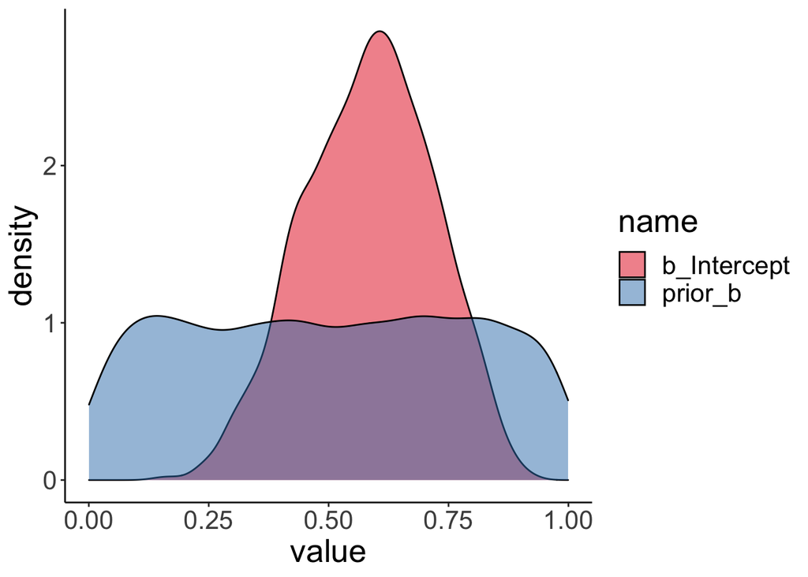

```r
fit.brm0 %>%
  posterior_samples(pars = "b") %>%
  pivot_longer(cols = everything()) %>%
  ggplot(mapping = aes(x = value,
                       fill = name)) +
  geom_density(alpha = 0.5) +
  scale_fill_brewer(palette = "Set1")
```

### 24.3.3 Hypothesis test

We test the H0: $\theta = 0.5$ versus the H1: $\theta \neq 0.5$ using the Savage-Dickey Method, according to which we can compute the Bayes factor like so:

$BF_{01} = \frac{p(D|H_0)}{p(D|H_1)} = \frac{p(\theta = 0.5|D, H_1)}{p(\theta = 0.5|H_1)}$

```r
fit.brm0 %>%
  hypothesis(hypothesis = "Intercept = 0.5")
```

```
#> Hypothesis Tests for class b:
#>              Hypothesis Estimate Est.Error CI.Lower CI.Upper Evid.Ratio
#> 1 (Intercept)-(0.5) = 0     0.08      0.13    -0.19     0.33       2.22
#>   Post.Prob Star
#> 1      0.69
#> ---
#> 'CI': 90%-CI for one-sided and 95%-CI for two-sided hypotheses.
#> '*': For one-sided hypotheses, the posterior probability exceeds 95%;
#> for two-sided hypotheses, the value tested against lies outside the 95%-CI.
#> Posterior probabilities of point hypotheses assume equal prior probabilities.
```

The result shows that the evidence ratio is in favor of the H0 with $BF_{01} = 2.22$. This means that H0 is 2.2 more likely than H1 given the data.

## 24.4 Dealing with heteroscedasticity

Let’s generate some fake developmental data where the variance in the data is greatest for young children, smaller for older children, and even smaller for adults:

```r
# make example reproducible
set.seed(0)

df.variance = tibble(group = rep(c("3yo", "5yo", "adults"), each = 20),
                     response = rnorm(n = 60,
                                      mean = rep(c(0, 5, 8), each = 20),
                                      sd = rep(c(3, 1.5, 0.3), each = 20)))
```

### 24.4.1 Visualize the data

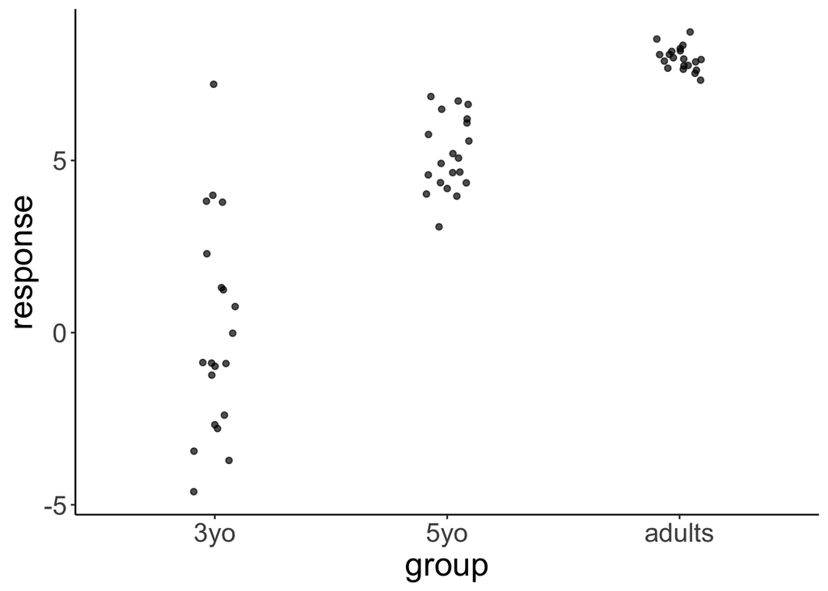

```r
df.variance %>%
  ggplot(aes(x = group, y = response)) +
  geom_jitter(height = 0,
              width = 0.1,
              alpha = 0.7)
```

### 24.4.2 Frequentist analysis

#### 24.4.2.1 Fit the model

```r
fit.lm1 = lm(formula = response ~ 1 + group,
             data = df.variance)

fit.lm1 %>%
  summary()
```

```
#>
#> Call:
#> lm(formula = response ~ 1 + group, data = df.variance)
#>
#> Residuals:
#>     Min      1Q  Median      3Q     Max
#> -4.6145 -0.8288 -0.0879  0.6315  7.2193
#>
#> Coefficients:
#>              Estimate Std. Error t value Pr(>|t|)
#> (Intercept) -0.005336   0.421618  -0.013     0.99
#> group5yo     5.172810   0.596258   8.675 5.25e-12 ***
#> groupadults  7.970655   0.596258  13.368  < 2e-16 ***
#> ---
#> Signif. codes:  0 '***' 0.001 '**' 0.01 '*' 0.05 '.' 0.1 ' ' 1
#>
#> Residual standard error: 1.886 on 57 degrees of freedom
#> Multiple R-squared:  0.7635, Adjusted R-squared:  0.7552
#> F-statistic: 91.99 on 2 and 57 DF,  p-value: < 2.2e-16
```

```r
fit.lm1 %>%
  glance() %>%
  kable(digits = 2) %>%
  kable_styling()
```

| r.squared | adj.r.squared | sigma | statistic | p.value | df | logLik | AIC | BIC | deviance | df.residual |
| --- | --- | --- | --- | --- | --- | --- | --- | --- | --- | --- |
| 0.76 | 0.76 | 1.89 | 91.99 | 0 | 3 | -121.65 | 251.3 | 259.68 | 202.65 | 57 |

#### 24.4.2.2 Visualize the model predictions

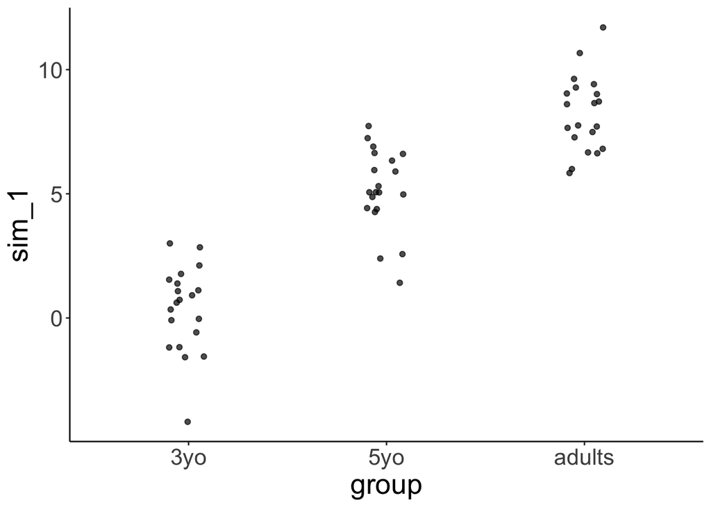

```r
set.seed(1)
fit.lm1 %>%
  simulate() %>%
  bind_cols(df.variance) %>%
  ggplot(aes(x = group, y = sim_1)) +
  geom_jitter(height = 0,
              width = 0.1,
              alpha = 0.7)
```

Notice how the model predicts that the variance is equal for each group.

### 24.4.3 Bayesian analysis

While frequentist models (such as a linear regression) assume equality of variance, Bayesian models afford us with the flexibility of inferring both the parameter estimates of the groups (i.e. the means and differences between the means), as well as the variances.

#### 24.4.3.1 Fit the model

We define a multivariate model which tries to fit both the `response` as well as the variance `sigma`:

```r
fit.brm1 = brm(formula = bf(response ~ group,
                            sigma ~ group),
               data = df.variance,
               file = "cache/brm1",
               seed = 1)

summary(fit.brm1)
```

```
#>  Family: gaussian
#>   Links: mu = identity; sigma = log
#> Formula: response ~ group
#>          sigma ~ group
#>    Data: df.variance (Number of observations: 60)
#> Samples: 4 chains, each with iter = 2000; warmup = 1000; thin = 1;
#>          total post-warmup samples = 4000
#>
#> Population-Level Effects:
#>                   Estimate Est.Error l-95% CI u-95% CI Rhat Bulk_ESS Tail_ESS
#> Intercept            -0.01      0.73    -1.41     1.51 1.01     1107     1072
#> sigma_Intercept       1.15      0.17     0.85     1.51 1.00     1991     1922
#> group5yo              5.18      0.77     3.60     6.65 1.00     1252     1327
#> groupadults           7.98      0.74     6.47     9.37 1.01     1110     1079
#> sigma_group5yo       -1.05      0.24    -1.51    -0.57 1.00     2249     2420
#> sigma_groupadults    -2.19      0.24    -2.66    -1.74 1.00     2171     2427
#>
#> Samples were drawn using sampling(NUTS). For each parameter, Bulk_ESS
#> and Tail_ESS are effective sample size measures, and Rhat is the potential
#> scale reduction factor on split chains (at convergence, Rhat = 1).
```

Notice that sigma is on the log scale. To get the standard deviations, we have to exponentiate the predictors, like so:

```r
fit.brm1 %>%
  tidy(parameters = "^b_") %>%
  filter(str_detect(term, "sigma")) %>%
  select(term, estimate) %>%
  mutate(term = str_remove(term, "b_sigma_")) %>%
  pivot_wider(names_from = term,
              values_from = estimate) %>%
  clean_names() %>%
  mutate_at(.vars = vars(-intercept), .funs = ~ exp(. + intercept)) %>%
  mutate(intercept = exp(intercept))
```

```
#> # A tibble: 1 x 3
#>   intercept group5yo groupadults
#>       <dbl>    <dbl>       <dbl>
#> 1      3.16     1.10       0.352
```

#### 24.4.3.2 Visualize the model predictions

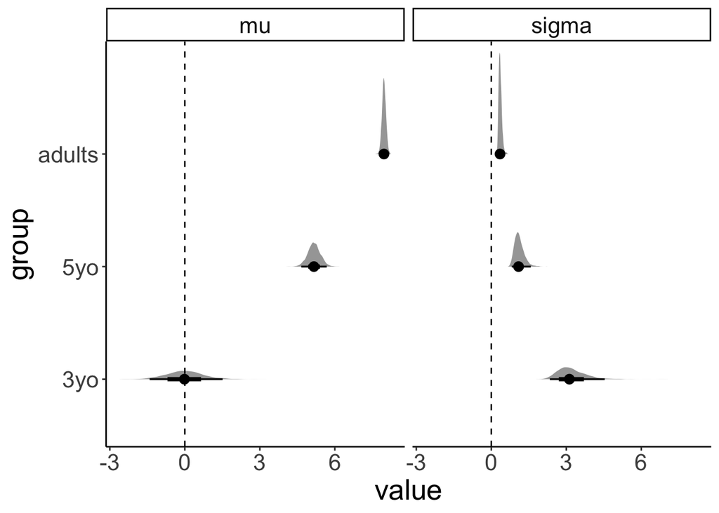

```r
df.variance %>%
  expand(group) %>%
  add_fitted_draws(fit.brm1, dpar = TRUE) %>%
  select(group, .row, .draw, posterior = .value, mu, sigma) %>%
  pivot_longer(cols = c(mu, sigma),
               names_to = "index",
               values_to = "value") %>%
  ggplot(aes(x = value, y = group)) +
  geom_halfeyeh() +
  geom_vline(xintercept = 0, linetype = "dashed") +
  facet_grid(cols = vars(index))
```

This plot shows what the posterior looks like for both mu (the inferred means), and for sigma (the inferred variances) for the different groups.

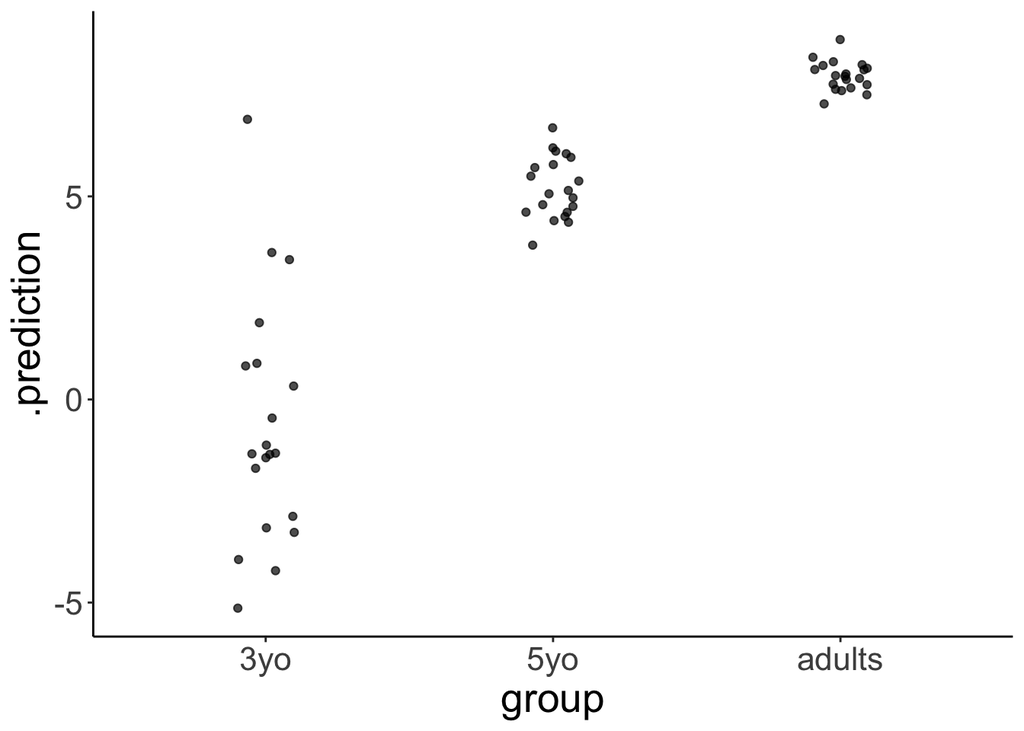

```r
set.seed(1)
df.variance %>%
  add_predicted_draws(model = fit.brm1,
                      n = 1) %>%
  ggplot(aes(x = group, y = .prediction)) +
  geom_jitter(height = 0,
              width = 0.1,
              alpha = 0.7)
```

## 24.5 Zero-one inflated beta binomial model

See this [blog post](https://vuorre.netlify.com/post/2019/02/18/analyze-analog-scale-ratings-with-zero-one-inflated-beta-models/#zoib-regression).

## 24.6 Ordinal regression

Check out the following two papers:

- Liddell and Kruschke (2018)
- Bürkner and Vuorre (2019)

Let’s read in some movie ratings:

```r
df.movies = read_csv(file = "data/MoviesData.csv")

df.movies = df.movies %>%
  pivot_longer(cols = n1:n5,
               names_to = "stars",
               values_to = "rating") %>%
  mutate(stars = str_remove(stars,"n"),
         stars = as.numeric(stars))

df.movies %>%
  head(10) %>%
  kable() %>%
  kable_styling()
```

| ID | Descrip | stars | rating |
| --- | --- | --- | --- |
| 1 | The Whole Truth | 1 | 49 |
| 1 | The Whole Truth | 2 | 70 |
| 1 | The Whole Truth | 3 | 119 |
| 1 | The Whole Truth | 4 | 217 |
| 1 | The Whole Truth | 5 | 245 |
| 2 | Priceless | 1 | 67 |
| 2 | Priceless | 2 | 22 |
| 2 | Priceless | 3 | 22 |
| 2 | Priceless | 4 | 60 |
| 2 | Priceless | 5 | 574 |

```r
df.movies = df.movies %>%
  uncount(weights = rating) %>%
  mutate(id = as.factor(ID)) %>%
  filter(ID <= 6)

df.movies %>%
  head(10) %>%
  kable() %>%
  kable_styling()
```

| ID | Descrip | stars | id |
| --- | --- | --- | --- |
| 1 | The Whole Truth | 1 | 1 |
| 1 | The Whole Truth | 1 | 1 |
| 1 | The Whole Truth | 1 | 1 |
| 1 | The Whole Truth | 1 | 1 |
| 1 | The Whole Truth | 1 | 1 |
| 1 | The Whole Truth | 1 | 1 |
| 1 | The Whole Truth | 1 | 1 |
| 1 | The Whole Truth | 1 | 1 |
| 1 | The Whole Truth | 1 | 1 |
| 1 | The Whole Truth | 1 | 1 |

### 24.6.1 Ordinal regression (assuming equal variance)

#### 24.6.1.1 Fit the model

```r
fit.brm5 = brm(formula = stars ~ 1 + id,
               family = cumulative(link = "probit"),
               data = df.movies,
               file = "cache/brm5",
               seed = 1)

summary(fit.brm5)
```

```
#>  Family: cumulative
#>   Links: mu = probit; disc = identity
#> Formula: stars ~ 1 + id
#>    Data: df.movies (Number of observations: 21708)
#> Samples: 4 chains, each with iter = 2000; warmup = 1000; thin = 1;
#>          total post-warmup samples = 4000
#>
#> Population-Level Effects:
#>              Estimate Est.Error l-95% CI u-95% CI Rhat Bulk_ESS Tail_ESS
#> Intercept[1]    -1.22      0.04    -1.31    -1.14 1.00     1877     2488
#> Intercept[2]    -0.90      0.04    -0.98    -0.82 1.00     1787     2419
#> Intercept[3]    -0.44      0.04    -0.52    -0.36 1.00     1692     2185
#> Intercept[4]     0.32      0.04     0.24     0.40 1.00     1634     2101
#> id2              0.84      0.06     0.71     0.96 1.00     2354     2553
#> id3              0.22      0.05     0.11     0.32 1.00     2146     2516
#> id4              0.33      0.04     0.24     0.41 1.00     1647     2315
#> id5              0.44      0.05     0.34     0.54 1.00     1982     2608
#> id6              0.75      0.04     0.67     0.83 1.00     1659     2158
#>
#> Samples were drawn using sampling(NUTS). For each parameter, Bulk_ESS
#> and Tail_ESS are effective sample size measures, and Rhat is the potential
#> scale reduction factor on split chains (at convergence, Rhat = 1).
```

#### 24.6.1.2 Visualizations

##### 24.6.1.2.1 Model parameters

The model infers the thresholds and the means of the Gaussian distributions in latent space.

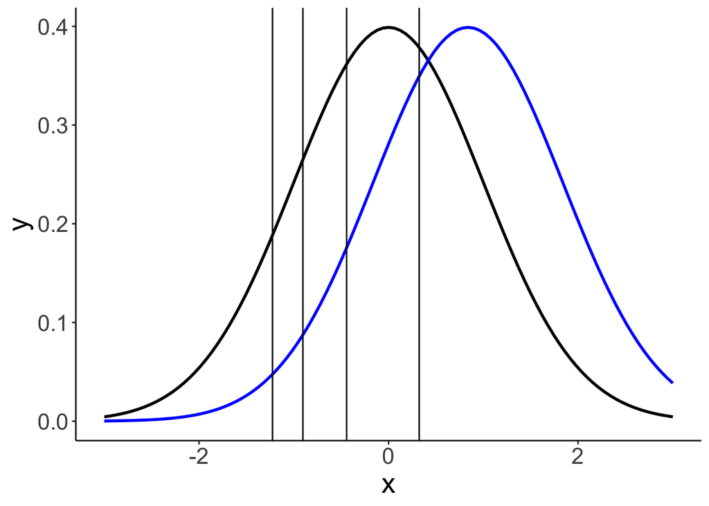

```r
df.params = fit.brm5 %>%
  tidy(parameters = "^b_") %>%
  select(term, estimate) %>%
  mutate(term = str_remove(term, "b_"))

ggplot(data = tibble(x = c(-3, 3)),
       mapping = aes(x = x)) +
  stat_function(fun = ~ dnorm(.),
                size = 1,
                color = "black") +
  stat_function(fun = ~ dnorm(., mean = df.params %>%
                                filter(str_detect(term, "id2")) %>%
                                pull(estimate)),
                size = 1,
                color = "blue") +
  geom_vline(xintercept = df.params %>%
               filter(str_detect(term, "Intercept")) %>%
               pull(estimate))
```

##### 24.6.1.2.2 MCMC inference

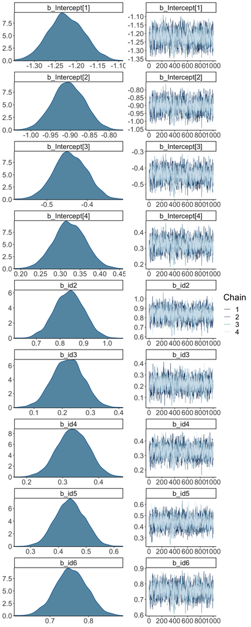

```r
fit.brm5 %>%
  plot(N = 9)
```

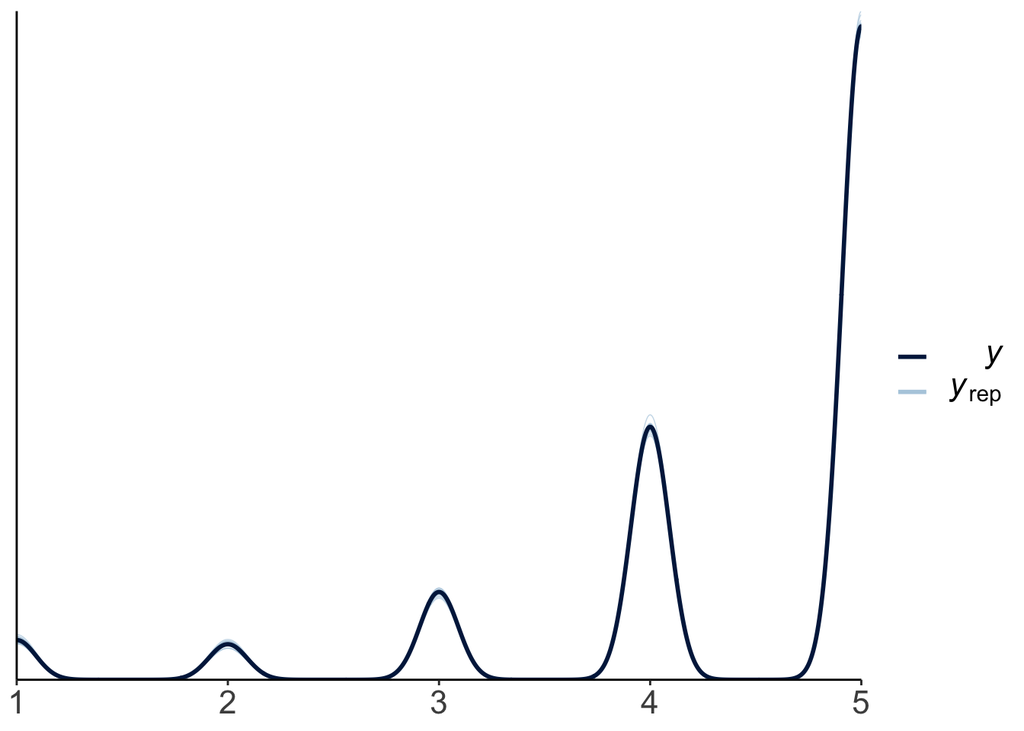

```r
fit.brm5 %>%
  pp_check(nsamples = 20)
```

##### 24.6.1.2.3 Model predictions

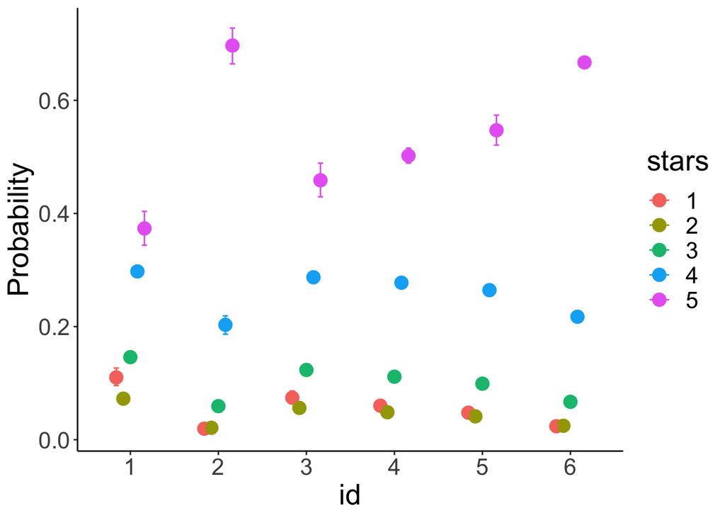

```r
conditional_effects(fit.brm5,
                    effects = "id",
                    categorical = T)
```

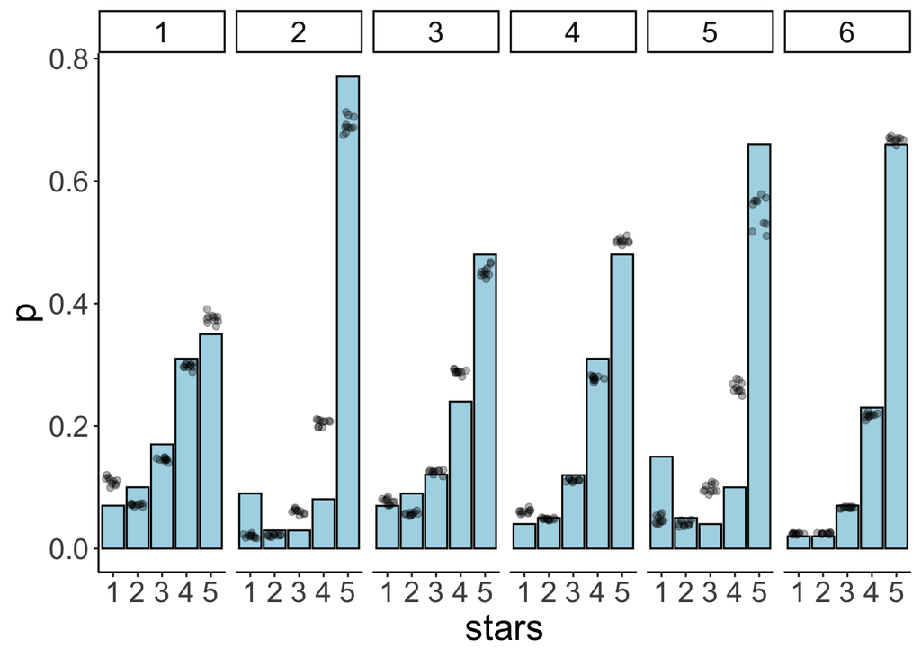

```r
df.model = add_fitted_draws(newdata = expand_grid(id = 1:6),
                           model = fit.brm5,
                           n = 10)

df.plot = df.movies %>%
  count(id, stars) %>%
  group_by(id) %>%
  mutate(p = n / sum(n)) %>%
  mutate(stars = as.factor(stars))

ggplot(data = df.plot,
       mapping = aes(x = stars,
                     y = p)) +
  geom_col(color = "black",
           fill = "lightblue") +
  geom_point(data = df.model,
             mapping = aes(x = .category,
                           y = .value),
             alpha = 0.3,
             position = position_jitter(width = 0.3)) +
  facet_wrap(~id, ncol = 6)
```

### 24.6.2 Gaussian regression (assuming equal variance)

#### 24.6.2.1 Fit the model

```r
fit.brm6 = brm(formula = stars ~ 1 + id,
               data = df.movies,
               file = "cache/brm6",
               seed = 1)

summary(fit.brm6)
```

```
#>  Family: gaussian
#>   Links: mu = identity; sigma = identity
#> Formula: stars ~ 1 + id
#>    Data: df.movies (Number of observations: 21708)
#> Samples: 4 chains, each with iter = 2000; warmup = 1000; thin = 1;
#>          total post-warmup samples = 4000
#>
#> Population-Level Effects:
#>           Estimate Est.Error l-95% CI u-95% CI Rhat Bulk_ESS Tail_ESS
#> Intercept     3.77      0.04     3.70     3.84 1.00     1203     1621
#> id2           0.64      0.05     0.54     0.75 1.00     1605     2335
#> id3           0.20      0.05     0.10     0.30 1.00     1558     2147
#> id4           0.37      0.04     0.29     0.45 1.00     1267     1862
#> id5           0.30      0.05     0.21     0.40 1.00     1441     2154
#> id6           0.72      0.04     0.65     0.79 1.00     1205     1720
#>
#> Family Specific Parameters:
#>       Estimate Est.Error l-95% CI u-95% CI Rhat Bulk_ESS Tail_ESS
#> sigma     1.00      0.00     0.99     1.01 1.00     3300     2723
#>
#> Samples were drawn using sampling(NUTS). For each parameter, Bulk_ESS
#> and Tail_ESS are effective sample size measures, and Rhat is the potential
#> scale reduction factor on split chains (at convergence, Rhat = 1).
```

#### 24.6.2.2 Visualizations

##### 24.6.2.2.1 Model predictions

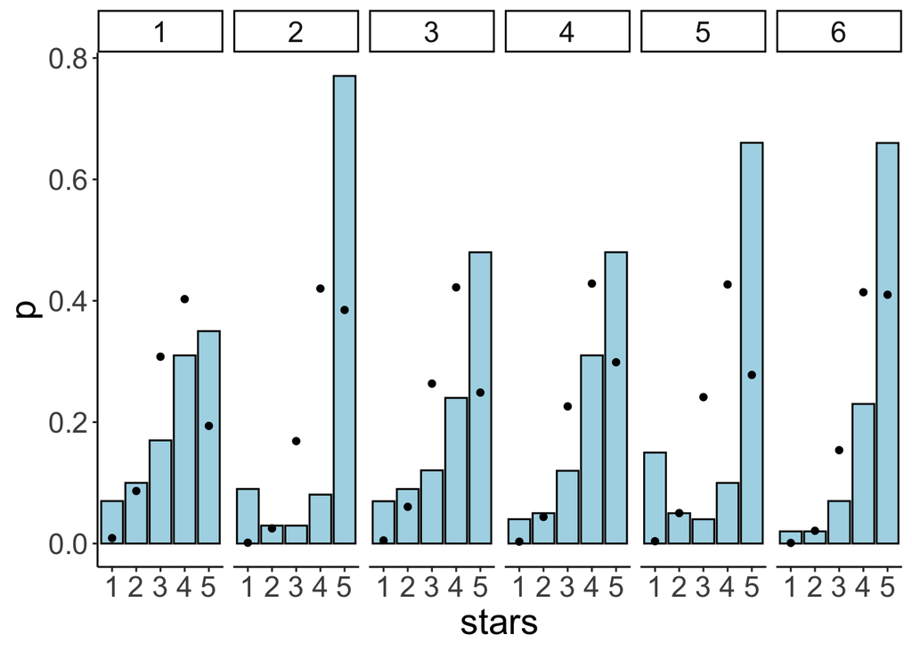

```r
# get the predictions for each value of the Likert scale
df.model = fit.brm6 %>%
  tidy(parameters = "^b_") %>%
  select(term, estimate) %>%
  mutate(term = str_remove(term, "b_")) %>%
  pivot_wider(names_from = term,
              values_from = estimate) %>%
  clean_names() %>%
  mutate_at(.vars = vars(id2:id6), .funs = ~ . + intercept) %>%
  set_names(str_c("mu_", 1:6)) %>%
  pivot_longer(cols = everything(),
               names_to = c("parameter", "movie"),
               names_sep = "_",
               values_to = "value") %>%
  pivot_wider(names_from = parameter,
              values_from = value) %>%
  mutate(data = map(.x = mu, .f = ~ tibble(x = 1:5,
                                           y  = dnorm(x, mean = .x)))) %>%
  select(movie, data) %>%
  unnest(c(data)) %>%
  group_by(movie) %>%
  mutate(y = y/sum(y)) %>%
  ungroup() %>%
  rename(id = movie)

# visualize the predictions
df.plot = df.movies %>%
  count(id, stars) %>%
  group_by(id) %>%
  mutate(p = n / sum(n)) %>%
  mutate(stars = as.factor(stars))

ggplot(data = df.plot,
       mapping = aes(x = stars,
                     y = p)) +
  geom_col(color = "black",
           fill = "lightblue") +
  geom_point(data = df.model,
            mapping = aes(x = x,
                          y = y)) +
  facet_wrap(~id, ncol = 6)
```

### 24.6.3 Oridnal regression (unequal variance)

#### 24.6.3.1 Fit the model

```r
fit.brm7 = brm(formula = bf(stars ~ 1 + id) + lf(disc ~ 0 + id, cmc = FALSE),
               family = cumulative(link = "probit"),
               data = df.movies,
               file = "cache/brm7",
               seed = 1)

summary(fit.brm7)
```

```
#>  Family: cumulative
#>   Links: mu = probit; disc = log
#> Formula: stars ~ 1 + id
#>          disc ~ 0 + id
#>    Data: df.movies (Number of observations: 21708)
#> Samples: 4 chains, each with iter = 2000; warmup = 1000; thin = 1;
#>          total post-warmup samples = 4000
#>
#> Population-Level Effects:
#>              Estimate Est.Error l-95% CI u-95% CI Rhat Bulk_ESS Tail_ESS
#> Intercept[1]    -1.41      0.06    -1.53    -1.29 1.00     1484     2421
#> Intercept[2]    -1.00      0.05    -1.10    -0.90 1.00     1852     2561
#> Intercept[3]    -0.46      0.04    -0.54    -0.37 1.00     2405     2684
#> Intercept[4]     0.41      0.05     0.32     0.51 1.00     1336     2161
#> id2              2.71      0.33     2.14     3.44 1.00     1681     1865
#> id3              0.33      0.07     0.20     0.47 1.00     1961     2618
#> id4              0.36      0.05     0.26     0.46 1.00     1525     2753
#> id5              1.65      0.17     1.34     2.00 1.00     1929     2281
#> id6              0.86      0.06     0.74     0.98 1.00     1112     1769
#> disc_id2        -1.12      0.10    -1.33    -0.94 1.00     1672     1943
#> disc_id3        -0.23      0.06    -0.34    -0.11 1.00     1342     1955
#> disc_id4        -0.01      0.04    -0.09     0.07 1.00     1043     1747
#> disc_id5        -1.09      0.07    -1.23    -0.95 1.00     1681     1996
#> disc_id6        -0.08      0.04    -0.15     0.00 1.00      941     1489
#>
#> Samples were drawn using sampling(NUTS). For each parameter, Bulk_ESS
#> and Tail_ESS are effective sample size measures, and Rhat is the potential
#> scale reduction factor on split chains (at convergence, Rhat = 1).
```

#### 24.6.3.2 Visualizations

##### 24.6.3.2.1 Model parameters

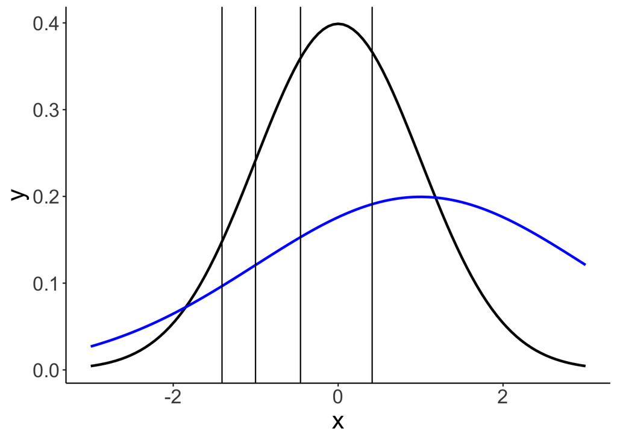

```r
df.params = fit.brm7 %>%
  tidy(parameters = "^b_") %>%
  select(term, estimate) %>%
  mutate(term = str_remove(term, "b_"))

ggplot(data = tibble(x = c(-3, 3)),
       mapping = aes(x = x)) +
  stat_function(fun = ~ dnorm(.),
                size = 1,
                color = "black") +
  stat_function(fun = ~ dnorm(.,
                              mean = 1,
                              sd = 2),
                size = 1,
                color = "blue") +
  geom_vline(xintercept = df.params %>%
               filter(str_detect(term, "Intercept")) %>%
               pull(estimate))
```

##### 24.6.3.2.2 Model predictions

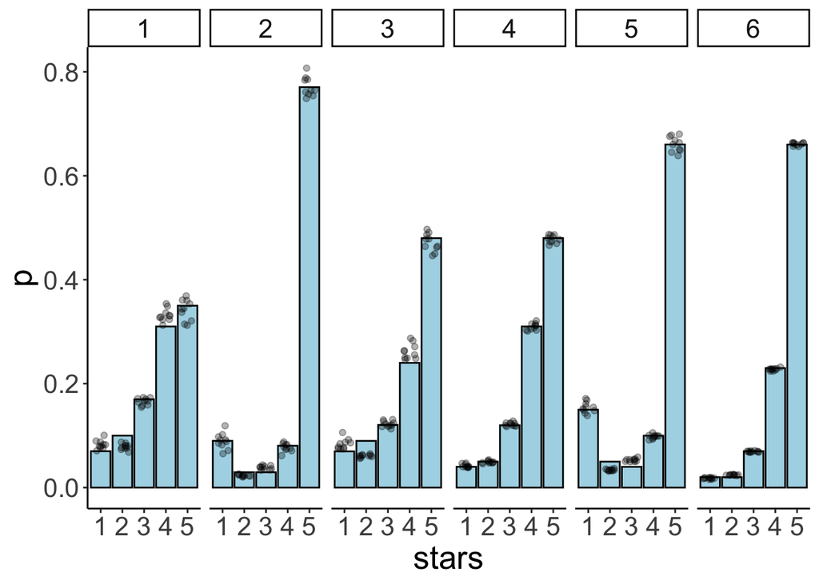

```r
df.model = add_fitted_draws(newdata = expand_grid(id = 1:6),
                           model = fit.brm7,
                           n = 10)

df.plot = df.movies %>%
  count(id, stars) %>%
  group_by(id) %>%
  mutate(p = n / sum(n)) %>%
  mutate(stars = as.factor(stars))

ggplot(data = df.plot,
       mapping = aes(x = stars,
                     y = p)) +
  geom_col(color = "black",
           fill = "lightblue") +
  geom_point(data = df.model,
             mapping = aes(x = .category,
                           y = .value),
             alpha = 0.3,
             position = position_jitter(width = 0.3)) +
  facet_wrap(~id, ncol = 6)
```

### 24.6.4 Gaussian regression (unequal variance)

#### 24.6.4.1 Fit the model

```r
fit.brm8 = brm(formula = bf(stars ~ 1 + id,
                            sigma ~ 1 + id),
               data = df.movies,
               file = "cache/brm8",
               seed = 1)

summary(fit.brm8)
```

```
#>  Family: gaussian
#>   Links: mu = identity; sigma = log
#> Formula: stars ~ 1 + id
#>          sigma ~ 1 + id
#>    Data: df.movies (Number of observations: 21708)
#> Samples: 4 chains, each with iter = 2000; warmup = 1000; thin = 1;
#>          total post-warmup samples = 4000
#>
#> Population-Level Effects:
#>                 Estimate Est.Error l-95% CI u-95% CI Rhat Bulk_ESS Tail_ESS
#> Intercept           3.77      0.05     3.68     3.86 1.00     1429     1985
#> sigma_Intercept     0.20      0.03     0.15     0.25 1.00     1530     1891
#> id2                 0.64      0.07     0.51     0.77 1.00     1888     2421
#> id3                 0.20      0.06     0.07     0.33 1.00     1866     2185
#> id4                 0.37      0.05     0.27     0.47 1.00     1500     2009
#> id5                 0.30      0.06     0.18     0.43 1.00     1904     2216
#> id6                 0.72      0.05     0.63     0.82 1.00     1416     2072
#> sigma_id2           0.02      0.04    -0.05     0.09 1.00     2095     2789
#> sigma_id3           0.03      0.04    -0.04     0.10 1.00     1874     2556
#> sigma_id4          -0.14      0.03    -0.19    -0.08 1.00     1669     2129
#> sigma_id5           0.20      0.03     0.14     0.27 1.00     1864     2203
#> sigma_id6          -0.35      0.03    -0.40    -0.30 1.00     1601     2009
#>
#> Samples were drawn using sampling(NUTS). For each parameter, Bulk_ESS
#> and Tail_ESS are effective sample size measures, and Rhat is the potential
#> scale reduction factor on split chains (at convergence, Rhat = 1).
```

#### 24.6.4.2 Visualizations

##### 24.6.4.2.1 Model predictions

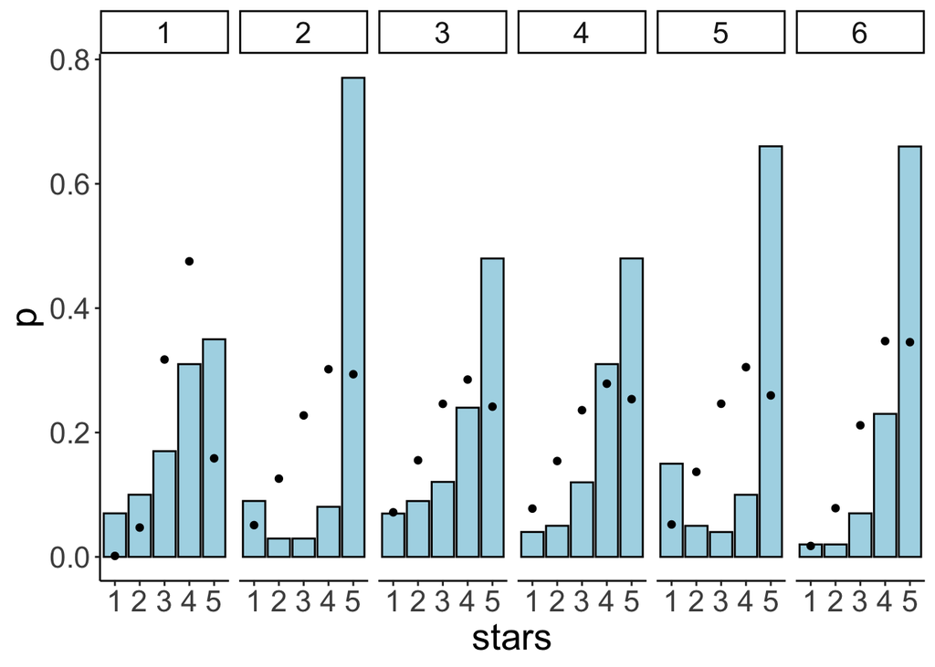

```r
df.model = fit.brm8 %>%
  tidy(parameters = "^b_") %>%
  select(term, estimate) %>%
  mutate(term = str_remove(term, "b_")) %>%
  pivot_wider(names_from = term,
              values_from = estimate) %>%
  clean_names() %>%
  mutate_at(.vars = vars(id2:id6), .funs = ~ . + intercept) %>%
  mutate_at(.vars = vars(contains("sigma")), .funs = ~ 1/exp(.)) %>%
  mutate_at(.vars = vars(sigma_id2:sigma_id5), .funs = ~ . + sigma_intercept) %>%
  set_names(c("mu_1", "sigma_1", str_c("mu_", 2:6), str_c("sigma_", 2:6))) %>%
  pivot_longer(cols = everything(),
               names_to = c("parameter", "movie"),
               names_sep = "_",
               values_to = "value") %>%
  pivot_wider(names_from = parameter,
              values_from = value) %>%
  mutate(data = map2(.x = mu, .y = sigma, .f = ~ tibble(x = 1:5,
                                                        y  = dnorm(x,
                                                       mean = .x,
                                                       sd = .y)))) %>%
  select(movie, data) %>%
  unnest(c(data)) %>%
  group_by(movie) %>%
  mutate(y = y/sum(y)) %>%
  ungroup() %>%
  rename(id = movie)

df.plot = df.movies %>%
  count(id, stars) %>%
  group_by(id) %>%
  mutate(p = n / sum(n)) %>%
  mutate(stars = as.factor(stars))

ggplot(data = df.plot,
       mapping = aes(x = stars,
                     y = p)) +
  geom_col(color = "black",
           fill = "lightblue") +
  geom_point(data = df.model,
            mapping = aes(x = x,
                          y = y)) +
  facet_wrap(~id, ncol = 6)
```

### 24.6.5 Model comparison

```r
# ordinal regression with equal variance
fit.brm5 = add_criterion(fit.brm5,
                         criterion = "loo")
```

```
#> Automatically saving the model object in 'cache/brm5.rds'
```

```r
# Gaussian regression with equal variance
fit.brm6 = add_criterion(fit.brm6,
                         criterion = "loo")
```

```
#> Automatically saving the model object in 'cache/brm6.rds'
```

```r
loo_compare(fit.brm5, fit.brm6)
```

```
#>          elpd_diff se_diff
#> fit.brm5     0.0       0.0
#> fit.brm6 -7657.1     109.2
```

## 24.7 Additional resources

- [Tutorial on visualizing brms posteriors with tidybayes](https://mjskay.github.io/tidybayes/articles/tidy-brms.html)
- [Hypothetical outcome plots](https://mucollective.northwestern.edu/files/2018-HOPsTrends-InfoVis.pdf)
- [Visual MCMC diagnostics](https://cran.r-project.org/web/packages/bayesplot/vignettes/visual-mcmc-diagnostics.html#general-mcmc-diagnostics)
- [Visualiztion of different MCMC algorithms](https://chi-feng.github.io/mcmc-demo/)

## References

Bürkner, Paul-Christian, and Matti Vuorre. 2019. “Ordinal Regression Models in Psychology: A Tutorial.” *Advances in Methods and Practices in Psychological Science*, 25.

Liddell, Torrin M., and John K. Kruschke. 2018. “Analyzing Ordinal Data with Metric Models: What Could Possibly Go Wrong?” *Journal of Experimental Social Psychology* 79 (November): 328–48. https://doi.org/10.1016/j.jesp.2018.08.009.

Wagenmakers, Eric-Jan, Tom Lodewyckx, Himanshu Kuriyal, and Raoul Grasman. 2010. “Bayesian Hypothesis Testing for Psychologists: A Tutorial on the SavageDickey Method.” *Cognitive Psychology* 60 (3): 158–89. https://doi.org/10.1016/j.cogpsych.2009.12.001.